# data_exp

Jenna Hopkins

2026-10-21

# Load packages and datasets

```r
library(tidyverse)

d3_instLevel = read_csv("../clean_data/d3_instLevel_ds.csv")
d3_sports = read_csv("../clean_data/d3_sports_ds.csv")
d3_coach = read_csv("../clean_data/d3_coach_ds.csv")

d3_sports = d3_sports %>%
  mutate(
    institution_name = case_when(
      str_starts(institution_name, "Linfield") ~ "Linfield University", #Linfield has a bunch names
      .default = institution_name
    )
  )

d3_instLevel = d3_instLevel %>%
  mutate(
    institution_name = case_when(
      str_starts(institution_name, "Linfield") ~ "Linfield University",
      .default = institution_name
    )
  )

d3_coach = d3_coach %>%
  mutate(
    institution_name = case_when(
      str_starts(institution_name, "Linfield") ~ "Linfield University",
      .default = institution_name
    )
  )

nwc = c(
  "Linfield University", "George Fox University", "Whitworth University", "Whitman College", "Pacific University", "University of Puget Sound", "Pacific Lutheran University", "Lewis & Clark College"
) #NWC teams

#
# d3_sports %>%
#   filter(str_starts(institution_name, "Linfield"))
```

# EDA plots

## Plot 1: Operating Expenses vs Number of Athletes

- Geometries: Points, ABline, text
- Aesthetics: x = number of athletes, y = operating expenses, color = type of school

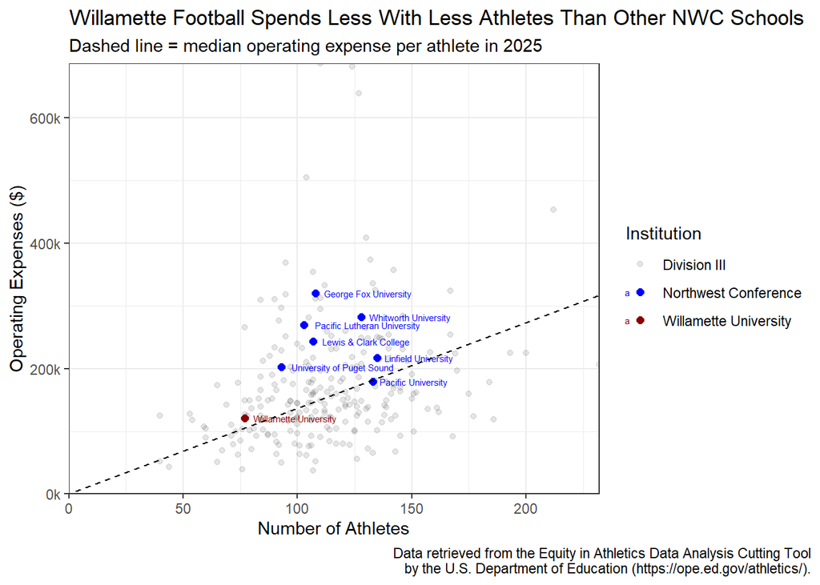

```r
selected_sport = "Men's Football" #User chooses
selected_year = 2025 #User chooses

title = paste0("Divison III ", selected_sport, " Operating Expenses vs Number of Athletes in ", as.numeric(selected_year)) #clean title

ds = d3_sports %>%
  filter(sport == selected_sport, year == selected_year) %>%
  mutate(
    color = case_when(
      institution_name %in% nwc ~ "Northwest Conference",
      institution_name == "Willamette University" ~ "Willamette University",
      .default = "Division III"
    ) #This is for later grouping
  )

colorpal = c(
  "Willamette University" = "darkred",
  "Northwest Conference" = "blue",
  "Division III" = "black"
)


solid = ds %>%
  filter(institution_name %in% nwc | institution_name == "Willamette University") #Solid points


ds %>%
  filter(!(institution_name %in% nwc), !(institution_name == "Willamette University")) %>%
  ggplot(aes(x = n_athletes, y = op_exp, color = color)) +
  geom_point(alpha = .1) +
  geom_point(data = solid, aes(x = n_athletes, y = op_exp, color = color), size = 2) +
  geom_text(data = solid, aes(label = institution_name), hjust = -.1, size = 2) +
  geom_abline(intercept = 0, slope = median(ds$op_exp, na.rm = TRUE)/median(ds$n_athletes), color = "black", linetype = "dashed") +
  scale_color_manual(values = colorpal) +
  scale_x_continuous(limits = c(0, max(ds$n_athletes)), expand = c(0, 0)) +
  scale_y_continuous(labels = function (x) paste0(x/1000, "k"), limits = c(0, max(ds$op_exp)), expand = c(0, 0)) +
  theme_bw() +
  theme(
    plot.caption.position = "plot" #Moving caption to the right side
  ) +
  labs(
    title = "Willamette Football Spends Less With Less Athletes Than Other NWC Schools",
    subtitle = "Dashed line = median operating expense per athlete in 2025",
    caption = "Data retrieved from the Equity in Athletics Data Analysis Cutting Tool\nby the U.S. Department of Education (https://ope.ed.gov/athletics/).",
    x = "Number of Athletes",
    y = "Operating Expenses ($)",
    color = "Institution"
  )
```

**Analysis** This is our main point, that Willamette spends less than other schools, which leads us with less opportunities for growth. By presenting this graphic which can show multiple different sports and years, we can show that this finding is consistent and change needs to be made.

## Plot 2: Operating Expenses per Athlete by Year

- Geometries: Points, smooth line
- Aesthetics: x = year, y = operating expenses per athlete, color = type of school

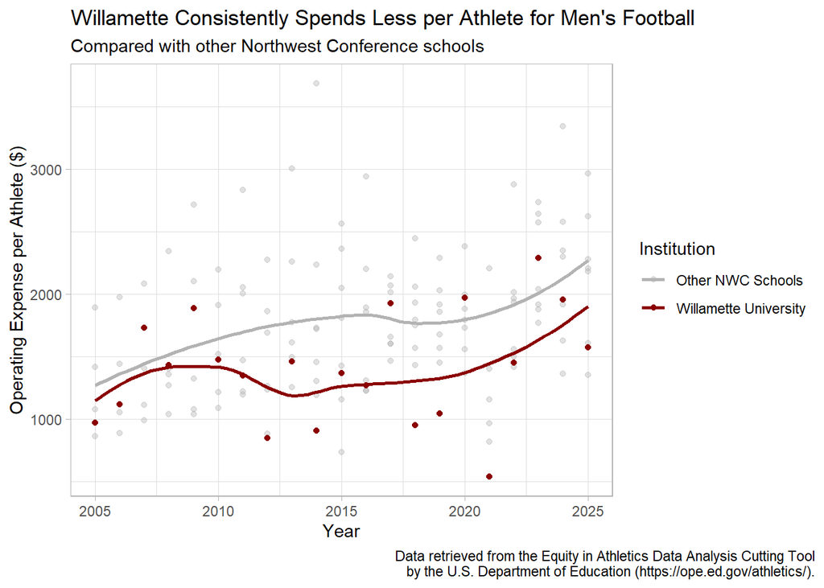

```r
selected_sport = "Men's Football" #User chooses

title = paste0("Willamette Consistently Spends Less per Athlete for ", selected_sport)

points = d3_sports %>%
  filter(sport == selected_sport, institution_name %in% nwc)

willamette = d3_sports %>%
  filter(sport == selected_sport, institution_name == "Willamette University")



points %>%
  ggplot(aes(x = year, y = op_exp_per_athlete)) +
  geom_point(alpha = .4, aes(color = "Other NWC Schools")) +
  geom_smooth(se = F, alpha = .5, aes(color = "Other NWC Schools")) +
  geom_point(data = willamette, aes(x = year, y = op_exp_per_athlete, color = "Willamette University")) +
  geom_smooth(data = willamette, se = F, aes(color = "Willamette University")) +
  theme_light() +
  theme(
    plot.caption.position = "plot" #Moving caption to the right side
  ) +
  scale_color_manual(
    values = c(
      "Willamette University" = "darkred",
      "Other NWC Schools" = "grey70"
    )
  ) +
  labs(
    title = title,
    subtitle = "Compared with other Northwest Conference schools",
    x = "Year",
    y = "Operating Expense per Athlete ($)",
    color = "Institution",
    caption = "Data retrieved from the Equity in Athletics Data Analysis Cutting Tool\nby the U.S. Department of Education (https://ope.ed.gov/athletics/)."
  )
```

**Analysis** This is our main point, that Willamette spends less than other schools, which leads us with less opportunities for growth. By presenting this graphic which can show multiple different sports over time, we can show that this finding is consistent and change needs to be made.

## Plot 3: Operating Expenses per Athlete by School

- Geometries: Points, boxplot
- Aesthetics: x = school, color = type of school

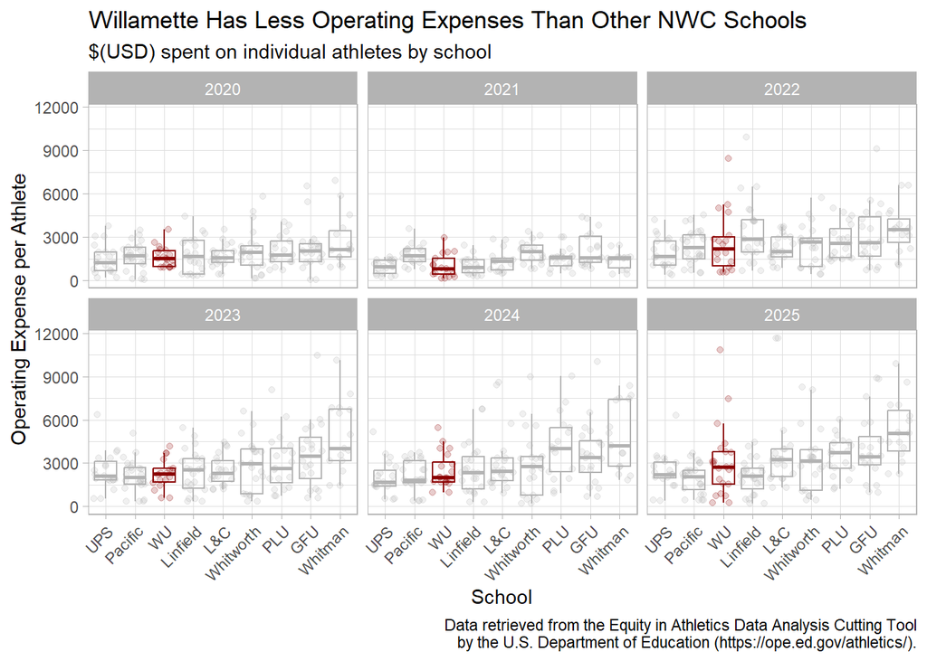

```r
d3_sports %>%
  filter(institution_name %in% nwc | institution_name == "Willamette University", year >= 2020) %>%
  ggplot(aes(x = fct_reorder(institution_name, op_exp_per_athlete, .fun = median), y = op_exp_per_athlete)) +
  geom_point(aes(color = institution_name == "Willamette University",
        group = institution_name), alpha = .2, position = "jitter") +
  geom_boxplot(aes(color = institution_name == "Willamette University", group = institution_name), alpha = 0) +
  facet_wrap(~year) + #Comparing between years
  theme_light() +
  theme(
    plot.caption.position = "plot", #Moving caption to the right side
    axis.text.x = element_text(angle = 45, hjust = 1)
  )  +
  scale_x_discrete(
    labels = c(
      "Willamette University" = "WU", "University of Puget Sound" = "UPS", "Lewis & Clark College" = "L&C", "Pacific Lutheran University" = "PLU", "Pacific University" = "Pacific", "Whitworth University" = "Whitworth", "George Fox University" = "GFU", "Linfield University" = "Linfield", "Whitman College" = "Whitman"
    )
  ) +
  scale_color_manual(
    values = c("TRUE" = "darkred", "FALSE" = "gray70"),
    guide = "none"
  ) +
  labs(
    x = "School",
    y = "Operating Expense per Athlete",
    title = "Willamette Has Less Operating Expenses Than Other NWC Schools",
    subtitle = "$(USD) spent on individual athletes by school",
    caption = "Data retrieved from the Equity in Athletics Data Analysis Cutting Tool\nby the U.S. Department of Education (https://ope.ed.gov/athletics/)."
  )
```

```
library(tidytext)


school_labels = c(
  "Willamette University" = "WU", "University of Puget Sound" = "UPS",
  "Lewis & Clark College" = "L&C", "Pacific Lutheran University" = "PLU",
  "Pacific University" = "Pacific", "Whitworth University" = "Whitworth",
  "George Fox University" = "GFU", "Linfield University" = "Linfield",
  "Whitman College" = "Whitman"
)


d3_sports %>%
  filter(institution_name %in% nwc | institution_name == "Willamette University", year == 2025, sport %in% wu_sports) %>%
  ggplot(aes(x = reorder_within(institution_name, total_hc + total_ac, sport), y = total_hc + total_ac)) +
  geom_col(aes(fill = institution_name == "Willamette University",
        group = institution_name)) +
  theme_light() +
  facet_wrap(
    ~ sport,
    scales = "free_x",
    labeller = as_labeller(c(
      "Women's Basketball" = "WBB",
      "Men's Basketball" = "MBB",
      "Women's Soccer" = "WSOC",
      "Men's Soccer" = "MSOC",
      "Women's Softball" = "Softball",
      "Men's Baseball" = "Baseball",
      "Men's Football" = "Football",
      "Women's Volleyball" = "Volleyball",
      "Men's Track and Field (Indoor)" = "M T&F (I)",
      "Men's Track and Field (Outdoor)" = "M T&F (O)",
      "Women's Track and Field (Indoor)" = "W T&F (I)",
      "Women's Track and Field (Outdoor)" = "W T&F (O)",
      "Women's Lacrosse" = "Lacrosse",
      "Men's Cross Country" = "M XC",
      "Women's Cross Country" = "W XC",
      "Men's Golf" = "M Golf",
      "Women's Golf" = "W Golf",
      "Men's Swimming" = "M Swim",
      "Women's Swimming" = "W Swim",
      "Women's Tennis" = "W Tennis",
      "Men's Tennis" = "M Tennis",
      "Women's Other Sports" = "W Other Sports"
    ))
  ) +
  scale_x_reordered(
    breaks = c()
  ) +
  scale_fill_manual(
    values = c("TRUE" = "darkred", "FALSE" = "gray70"),
    labels = c("TRUE" = "Willamette", "FALSE" = "Other NWC")
  ) +
  labs(
    x = "",
    y = "Total Number of Coaches",
    fill = "School",
    title = "Is Willamette Undercoached?",
    subtitle = "Total # of coaches by sport in the NWC"
  )
```

## Plot 4: Headcoach Salary vs Year

- Geometries: Lines
- Aesthetics: x = year, y = head coach salaries, color = type of school

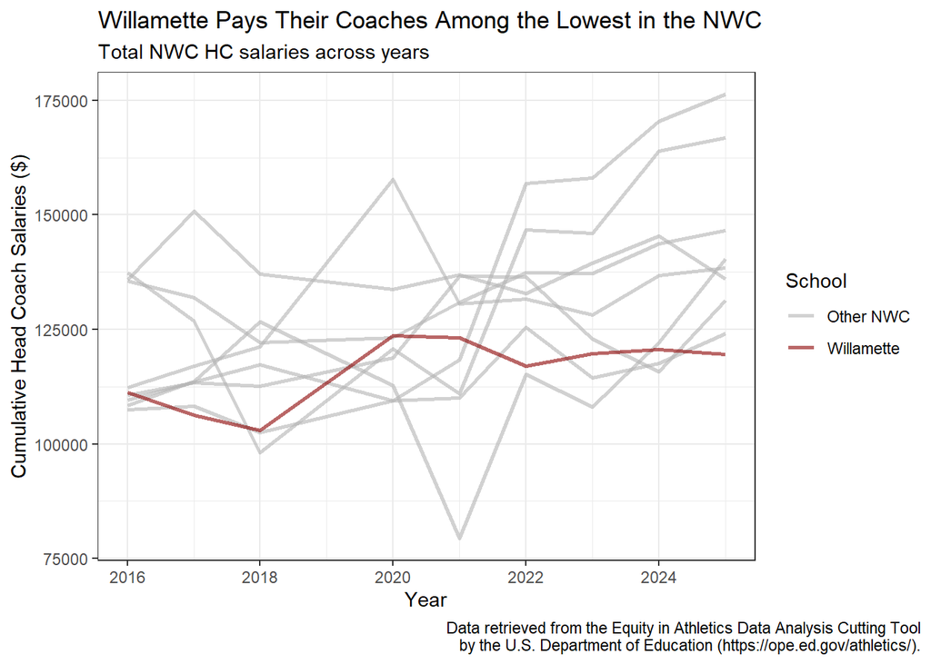

```r
d3_instLevel %>%
  mutate(HC_sal = HDCOACH_SAL_FTE_MEN+HDCOACH_SAL_FTE_WOMN) %>% #Adding averages of full time HC sal
  filter(institution_name %in% nwc| institution_name == "Willamette University")%>%
  ggplot(aes(x = year, y = HC_sal)) +
  geom_line(linewidth = 1, alpha = .6, aes(color = institution_name == "Willamette University",
        group = institution_name)) +
  scale_x_continuous(breaks = c(2016,2018,2020,2022,2024))+
  scale_color_manual(
    values = c("TRUE" = "darkred", "FALSE" = "gray70"),
    labels = c("TRUE" = "Willamette", "FALSE" = "Other NWC")
  )+
  theme_bw() +
  theme(
    plot.caption.position = "plot" #Moving caption to the right side
  ) +
  labs(
    title ="Willamette Pays Their Coaches Among the Lowest in the NWC",
    subtitle = "Total NWC HC salaries across years",
    y = "Cumulative Head Coach Salaries ($)",
    x = "Year",
    color = "School",
    caption = "Data retrieved from the Equity in Athletics Data Analysis Cutting Tool\nby the U.S. Department of Education (https://ope.ed.gov/athletics/)."
  )
```

**Analysis** Willamette, on average, per individual coach, ranks the lowest in 2025 in the Northwest Conference. This is significant because Willamette sports are continuing to generally struggle. Inability to pay top candidates hurts the ability of our teams to be the most competitive they can, because development of our athletes is limited. Investing higher amounts in coaches is needed to observe change instead of seeing a continuous slump.

```
d3_instLevel %>%
  mutate(HC_sal = HDCOACH_SAL_FTE_MEN+HDCOACH_SAL_FTE_WOMN) %>%
  filter(institution_name %in% nwc| institution_name == "Willamette University")%>%
  ggplot(aes(x = year, y = HC_sal, color = institution_name)) +
  geom_line(linewidth = 1, alpha = .6) +
  scale_x_continuous(breaks = c(2016,2018,2020,2022,2024))+
  # scale_color_manual(
  #   values = c("TRUE" = "darkred", "FALSE" = "gray70"),
  #   guide = "none"
  # )+
  theme_bw()
```

```
nwc_med = d3_instLevel %>%
  filter(institution_name %in% nwc) %>%
  summarize(
    .by = year,
    med_opexp_athlete = median(IL_TOTAL_OPEXP_INCLCOED/(UNDUP_CT_PARTIC_MEN + UNDUP_CT_PARTIC_WOMEN)),
    med_exp_athlete = median(GRND_TOTAL_EXPENSE/(UNDUP_CT_PARTIC_MEN + UNDUP_CT_PARTIC_WOMEN))
  )

wu_med = d3_instLevel %>%
  filter(institution_name == "Willamette University") %>%
  summarize(
    .by = year,
    med_opexp_athlete = median(IL_TOTAL_OPEXP_INCLCOED/(UNDUP_CT_PARTIC_MEN + UNDUP_CT_PARTIC_WOMEN)),
    med_exp_athlete = median(GRND_TOTAL_EXPENSE/(UNDUP_CT_PARTIC_MEN + UNDUP_CT_PARTIC_WOMEN))
    )


nwc_med %>%
  ggplot(aes(x = year)) +

  # Other NWC schools: operating expenses (dashed)
  geom_point(aes(y = med_opexp_athlete, color = "Other NWC Schools")) +
  geom_line(aes(y = med_opexp_athlete, color = "Other NWC Schools", linetype = "Operating Expenses")) +

  # Other NWC schools: total expenses (solid)
  geom_point(aes(y = med_exp_athlete, color = "Other NWC Schools")) +
  geom_line(aes(y = med_exp_athlete, color = "Other NWC Schools", linetype = "Total Expenses")
  ) +

  # Willamette: operating expenses (dashed)
  geom_point(data = wu_med, aes(y = med_opexp_athlete, color = "Willamette University")) +
  geom_line(data = wu_med, aes(y = med_opexp_athlete, color = "Willamette University", linetype = "Operating Expenses")) +

  # Willamette: total expenses (solid)
  geom_point(data = wu_med, aes(y = med_exp_athlete, color = "Willamette University")) +
  geom_line(data = wu_med, aes(y = med_exp_athlete, color = "Willamette University", linetype = "Total Expenses")) +

  scale_color_manual(
    name = "Institution",
    values = c(
      "Other NWC Schools" = "grey60",
      "Willamette University" = "darkred"
    )
  ) +
  scale_linetype_manual(
    name = "Expense Type",
    values = c(
      "Operating Expenses" = "dashed",
      "Total Expenses" = "solid"
    )
  ) +
  scale_x_continuous(
    breaks = seq(2000, 2025, by = 1)
  ) +
  theme_light() +
  labs(
    title = "Less of Willamette's Athletic Expenses Go Directly to Athletes",
    subtitle = "Compared with other NWC schools",
    x = "Year",
    y = "Expenses per Athlete ($)"
  )
```

```
nwc_ = d3_instLevel %>%
  filter(institution_name %in% nwc)

wu = d3_instLevel %>%
  filter(institution_name == "Willamette University")

nwc_ %>%
  bind_rows(wu) %>%
  ggplot(aes(x = year, y = RECRUITEXP_TOTAL/(UNDUP_CT_PARTIC_MEN + UNDUP_CT_PARTIC_WOMEN))) +
  geom_point(aes(color = institution_name == "Willamette University")) +
  geom_smooth(data = wu, se = F, color = "darkred") +
  geom_smooth(data = nwc_, se = F, color = "grey70") +
  theme_light() +
  scale_color_manual(
    values = c("TRUE" = "darkred", "FALSE" = "gray70"),
    labels = c("TRUE" = "Willamette", "FALSE" = "Other NWC")
  ) +
  scale_x_continuous(
    breaks = seq(2000, 2025, by = 1)
  ) +
  labs(
    title = "How Much is Spent on Recruiting Over Time",
    x = "Year",
    y = "Amount Spent on Recruiting per Athlete ($)",
    color = "Institution"
  )
```

## Plot 5: Percent Difference in Expense Categories from NWC Median

- Geometries: Columns, vline
- Aesthetics: x = difference in percentage, y = expense category, fill = positive/negative

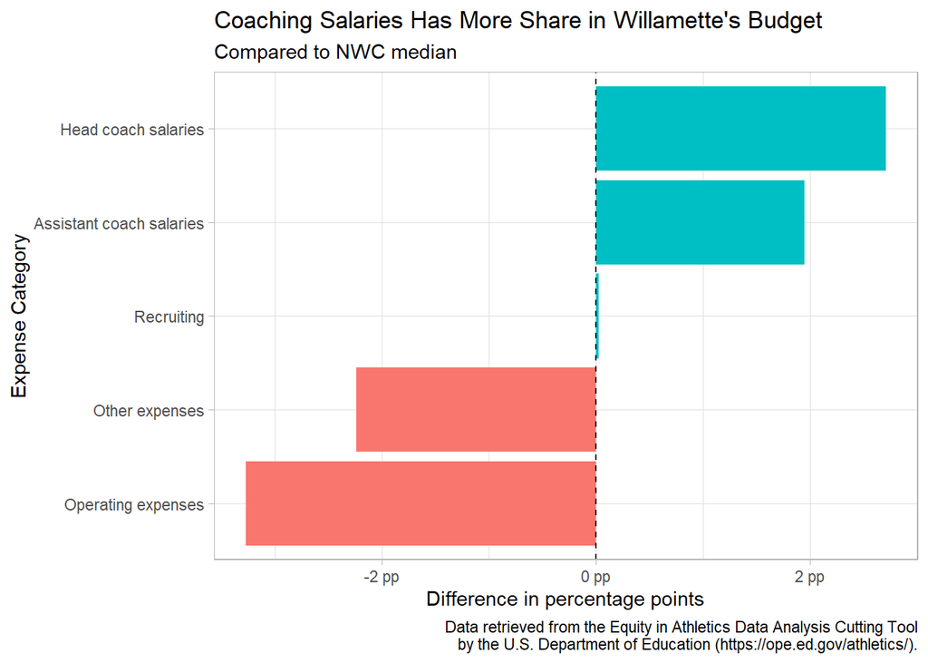

```r
expense_breakdown = d3_instLevel %>%
  filter(institution_name %in% nwc | institution_name == "Willamette University") %>%
  mutate(
    hc_salaries =
      coalesce(HDCOACH_SALARY_MEN * NUM_HDCOACH_MEN, 0) + #Making 0 if NA
      coalesce(HDCOACH_SALARY_WOMEN * NUM_HDCOACH_WOMEN, 0) +
      coalesce(HDCOACH_SALARY_COED * NUM_HDCOACH_COED, 0),

    ac_salaries =
      coalesce(ASCOACH_SALARY_MEN * NUM_ASCOACH_MEN, 0) +
      coalesce(ASCOACH_SALARY_WOMEN * NUM_ASCOACH_WOMEN, 0) +
      coalesce(ASCOACH_SALARY_COED * NUM_ASCOACH_COED, 0),

    recruiting =
      coalesce(RECRUITEXP_MEN, 0) +
      coalesce(RECRUITEXP_WOMEN, 0) +
      coalesce(RECRUITEXP_COED, 0),

    operating = IL_TOTAL_OPEXP_INCLCOED,

    other = GRND_TOTAL_EXPENSE - operating - recruiting - hc_salaries - ac_salaries
  )


selected_year = 2025 #User chooses
title = paste0("Where Willamette's Athletic Spending Differed in ", selected_year) #User chooses

expense_breakdown %>%
  filter(year == selected_year) %>%
  mutate(
    operating = operating / GRND_TOTAL_EXPENSE * 100,
    recruiting = recruiting / GRND_TOTAL_EXPENSE * 100,
    hc_salaries = hc_salaries / GRND_TOTAL_EXPENSE * 100,
    ac_salaries = ac_salaries / GRND_TOTAL_EXPENSE * 100,
    other = other / GRND_TOTAL_EXPENSE * 100
  ) %>%
  select(
    institution_name,
    operating,
    recruiting,
    hc_salaries,
    ac_salaries,
    other
  ) %>%
  pivot_longer(
    cols = -institution_name,
    names_to = "category",
    values_to = "percentage"
  ) %>%
  group_by(category) %>%
  mutate(
    nwc_median = median(
      percentage[institution_name %in% nwc],
      na.rm = TRUE
    )
  ) %>%
  ungroup() %>%
  filter(institution_name == "Willamette University") %>%
  mutate(
    difference = percentage - nwc_median,
    category = recode(
      category,
      operating = "Operating expenses",
      recruiting = "Recruiting",
      hc_salaries = "Head coach salaries",
      ac_salaries = "Assistant coach salaries",
      other = "Other expenses"
    )
  ) %>%
  ggplot(aes(x = difference, y = reorder(category, difference), fill = difference > 0)) +
  geom_col() +
  geom_vline(xintercept = 0, linetype = "dashed") +
  scale_x_continuous(
    labels = \(x) paste0(x, " pp")
  ) +
  theme_light() +
  theme(
    legend.position = "none",
    plot.caption.position = "plot" #Moving caption to the right side
  ) +
  labs(
    title = "Coaching Salaries Has More Share in Willamette's Budget",
    subtitle = "Compared to NWC median",
    x = "Difference in percentage points",
    y = "Expense Category",
    caption = "Data retrieved from the Equity in Athletics Data Analysis Cutting Tool\nby the U.S. Department of Education (https://ope.ed.gov/athletics/)."
  )
```

```
expense_breakdown %>%
  filter(year == 2025) %>%
  select(institution_name, operating, recruiting, hc_salaries, ac_salaries, other) %>%
  pivot_longer(
    cols = c(operating, recruiting, hc_salaries, ac_salaries, other),
    names_to = "category",
    values_to = "expense"
  ) %>%
  ggplot(aes(
    x = institution_name,
    y = expense,
    fill = category
  )) +
  geom_col() +
  labs(
    x = NULL,
    y = "Grand Total Expenses ($)",
    fill = "Expense Category"
  ) +
  theme_light() +
  theme(
    axis.text.x = element_text(angle = 45, hjust = 1)
  )


expense_breakdown %>%
  filter(year == 2025) %>%
  select(
    institution_name,
    operating, recruiting,
    hc_salaries, ac_salaries, other
  ) %>%
  pivot_longer(
    cols = c(operating, recruiting, hc_salaries, ac_salaries, other),
    names_to = "category",
    values_to = "expense"
  ) %>%
  ggplot(aes(
    x = reorder(institution_name, expense),
    y = expense,
```

[output cut: 82 more lines]

```
  group_by(institution_name) %>%
  mutate(
    category = reorder(category, percentage)
  ) %>%
  ungroup() %>%
  ggplot(aes(x = percentage, y = category)) +
  geom_col(fill = "gray65") +
  facet_wrap(~ institution_name, scales = "free_y") +
  labs(
    x = "Percent of Grand Total Expenses",
    y = NULL,
    title = "Athletic Expense Composition by School",
    subtitle = "2025"
  ) +
  theme_light()
```

```
expense_breakdown %>%
  mutate(
    operating_pct = operating / GRND_TOTAL_EXPENSE * 100
  ) %>%
  group_by(year) %>%
  mutate(
    nwc_median = median(operating_pct[institution_name %in% nwc], na.rm = TRUE)
  ) %>%
  ungroup() %>%
  filter(institution_name == "Willamette University") %>%
  ggplot(aes(x = year)) +
  geom_line(aes(y = operating_pct, color = "Willamette University"), linewidth = 1) +
  geom_line(aes(y = nwc_median, color = "Other NWC Schools"), linewidth = 1, linetype = "dashed") +
  labs(
    title = "Operating Expenses as a Share of Athletics Spending",
    x = "Year",
    y = "Operating expenses (% of total)",
    color = "Institution"
  ) +
  scale_color_manual(
    values = c(
      "Other NWC Schools" = "grey60",
      "Willamette University" = "darkred"
    )
  ) +
  scale_y_continuous(
    labels = \(x) paste0(x, "%")
  ) +
  scale_x_continuous(
    breaks = seq(2000, 2025, by = 1)
  ) +
  theme_light()
```